# FISH 497 Assignment 5

Kristin Privitera-Johnson

20 February 2021

# Data exploration

## Data description

The data come from the [{FSAdata}](https://github.com/droglenc/FSAdata) package, which was created by [Derek Ogle](https://derekogle.com/) as part of his book [*Introductory Fisheries Analysis with R*](http://derekogle.com/IFAR/). The dataset contains information on the ages (subsample), and length and mass (all fish) for male and female Siscowet Lake Trout captured at four locations in Michigan waters of Lake Superior.

## Format

A data frame with 780 observations on the following 8 variables.

1. `locID`: Locations (`Blind Sucker`, `Deer Park`, `Grand Marais`, `Little Lake Harbor`)
2. `pnldep`: Depth of gillnet panel in which the fish was captured
3. `mesh`: Gillnet stretch mesh measure
4. `fishID`: Unique fish identification code
5. `sex`: Sex (`F` = female; `M` = male)
6. `age`: Assigned ages (years)
7. `len`: Total length (mm)
8. `wgt`: Weight (g)

## Read in the data

First, I read in the data and checked for missing observations. Not the most elegant approach, but quicker than scrolling through 780 rows of 8 variables.

```r
fish <- read.csv("siscowet.csv")
head(fish)
```

```
##       locID pnldep mesh fishID  sex age len  wgt
## 1 Deer Park  36.74  2.5  19108 <NA>  NA 316  400
## 2 Deer Park  40.09  3.0  19109 <NA>  NA 396  700
## 3 Deer Park  41.46  5.0  19110    M  NA 590 1800
## 4 Deer Park  41.46  5.0  19111    M  NA 516 1500
## 5 Deer Park  43.45  5.5  19112 <NA>  NA 414  800
## 6 Deer Park  45.58  4.0  19113    M  NA 481 1000
```

```r
# Which variables have NAs?
TF <- apply(X=fish, MARGIN=2, FUN=is.na)
apply(X=TF, MARGIN=2, FUN=table)
```

```
## $locID
##
## FALSE
##   780
##
## $pnldep
##
## FALSE
##   780
##
## $mesh
##
## FALSE
##   780
##
## $fishID
##
## FALSE
##   780
##
## $sex
##
## FALSE  TRUE
##   721    59
##
## $age
##
## FALSE  TRUE
##   200   580
##
## $len
##
## FALSE
##   780
##
## $wgt
##
## FALSE  TRUE
##   779     1
```

There are quite a few `NA` values. Let’s see how these affect some typical fisheries relationships.

## What is the spread of the data?

```r
# Set up data inputs for by sex questions
age_m <- fish$age[fish$sex=="M"]
age_f <- fish$age[fish$sex=="F"]
len_m <- fish$len[fish$sex=="M"]
len_f <- fish$len[fish$sex=="F"]
wgt_m <- fish$wgt[fish$sex=="M"]
wgt_f <- fish$wgt[fish$sex=="F"]
```

First, I’m interested in how much data we may have for length and age.

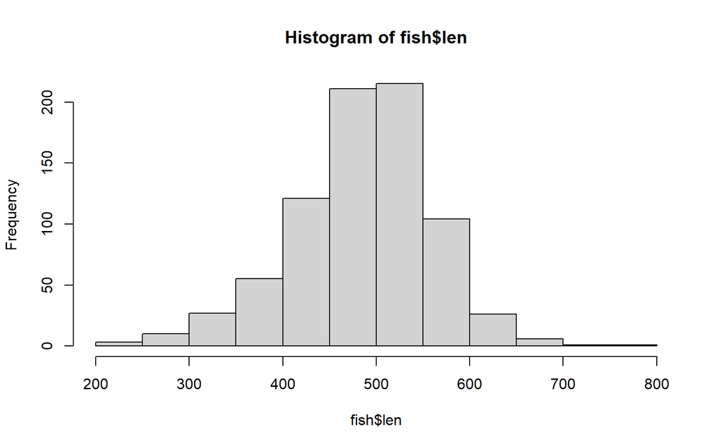

```r
# How much data do we have?
hist(fish$len)
```

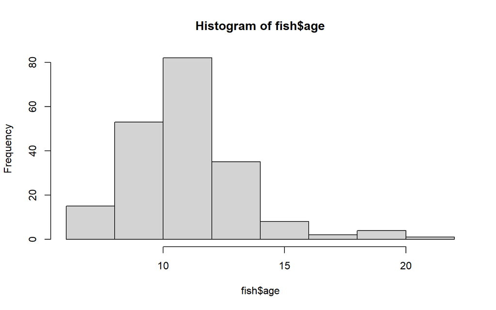

```r
hist(fish$age)
```

Looks like we have lengths for every fish sampled (no `NA`s) and those data seem centered around 500 mm. There are only 200 observations of age across the four sampling locations. Of those data, it seems we have a skewed age plot–most trout seem to be somewhere around 10 years old, but there are a few plus group members hanging out at closer to 20 years old.

I don’t know much about trout, so I’d like to see the shape of the age-length relationship.

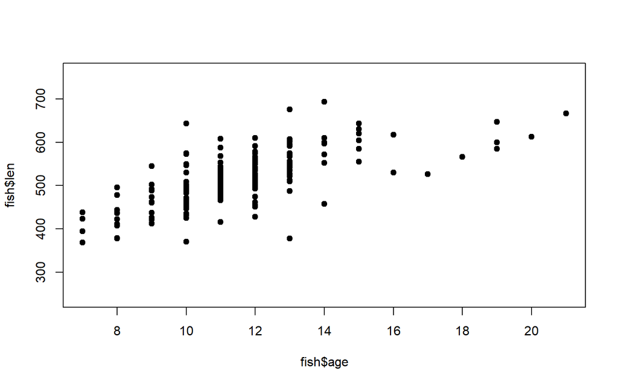

```r
# What is the age-length relationship (both sexes)?
plot(x=fish$age,
     y=fish$len,
     pch=19)
```

Could be flat, could be asymptotic. It’s a shame I can only look at 200 observations of the 780, but perhaps we shouldn’t be killing every trout surveyed. Moving on, I wonder if the observed trout exhibit sexual dimorphism.

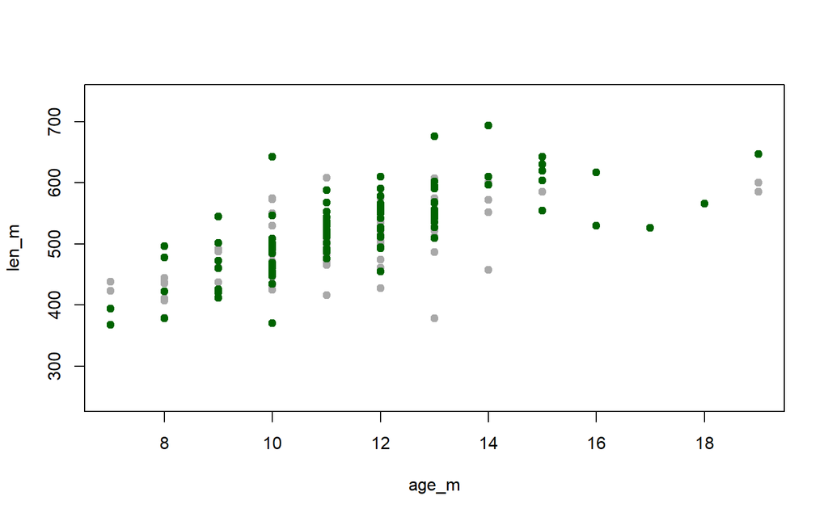

```r
# How do the age-length curves look by sex? ####
plot(x=age_m,
     y=len_m,
     pch=19,
     col="darkgray")

points(x=age_f,
       y=len_f,
       pch=19,
       col="darkgreen")
```

Maybe not! I see there are some weight data as well.

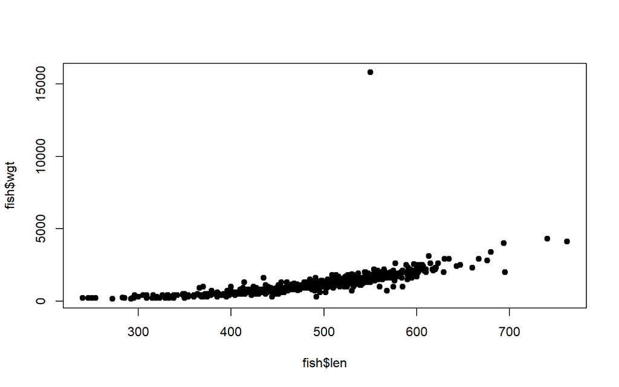

```r
# What is the length-weight relationship (both sexes)?

plot(x=fish$len,
     y=fish$wgt,
     pch=19)
```

Hello there, really big trout. What is your story?

```r
# Who are you?
out <- which(fish$wgt > 5000)
fish[out,]
```

```
##                  locID pnldep mesh fishID sex age len   wgt
## 541 Little Lake Harbor  40.85    3  19234   F  12 550 15800
```

```r
# How do you compare to the others?
summary(fish$wgt)
```

```
##    Min. 1st Qu.  Median    Mean 3rd Qu.    Max.    NA's
##     150     775    1100    1175    1500   15800       1
```

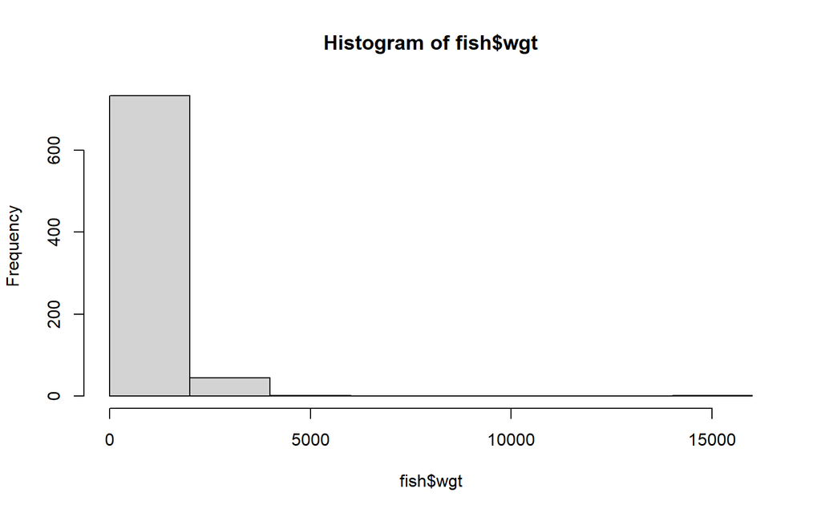

```r
hist(fish$wgt)
```

Is she a BOFFF?! Or a different species? Or someone added an extra 0? I’ll never know. Let’s set her aside for a bit. I also note that there is only one missing weight observation here.

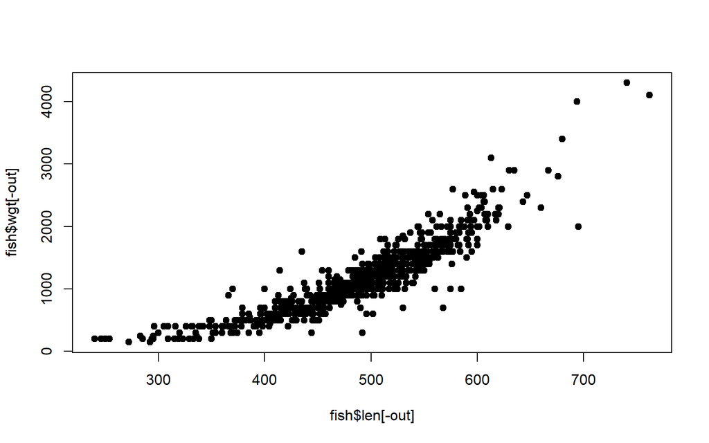

```r
# How do all the other fish look without the outlier?
plot(x=fish$len[-out],
     y=fish$wgt[-out],
     pch=19)
```

This is more what I’m used to seeing. Let’s see if there’s any difference between sexes.

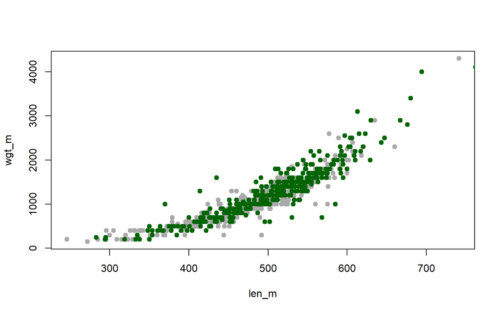

```r
# How do the length-weight curves look by sex?
plot(x=len_m,
     y=wgt_m,
     pch=19,
     col="darkgray")

points(x=len_f,
       y=wgt_f,
       pch=19,
       col="darkgreen")
```

Perhaps not.

## Location, location

Here, I attempt to check out length and age across locations. I immediately threw an error with the first location because it appears that age data were not collected there, so the code below is adapted to skip that particular question at that location.

```r
# Locations
loca <- unique(fish$locID)
colr <- c("darkgray", "darkgreen", "darkblue", "pink")
counter <- 0

for (i in 1:length(loca)) {
  rindex <- which(fish$locID==loca[i])
  age <- fish[rindex,"age"]
  len <- fish[rindex,"len"]

  if (all(is.na(age) | is.na(len))) {
    print(paste(loca[i], "did not collect age or len data. Check."))

  } else {
    counter <- counter + 1

    if (counter==1) {
      plot(x=age,
           y=len,
           pch=19,
           col=colr[i])

    } else {
      points(x=age,
             y=len,
             pch=19,
             col=colr[i])
    }
  }
}
```

```
## [1] "Deer Park did not collect age or len data. Check."
```

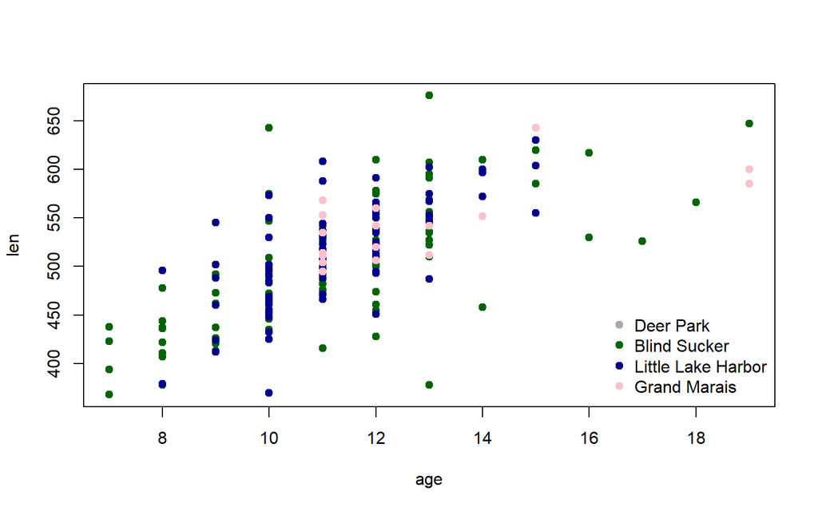

```r
legend(x="bottomright",
       legend=loca,
       col=colr,
       pch=19,
       bty="n")
```

There is no representation from Deer Park. Investigating the Grand Marais may be interesting given the sample does not have any fish younger than 11. I don’t immediately see much contrast between Blind Sucker and Little Lake Harbor. Let’s check out the distribution of ages and lengths by location.

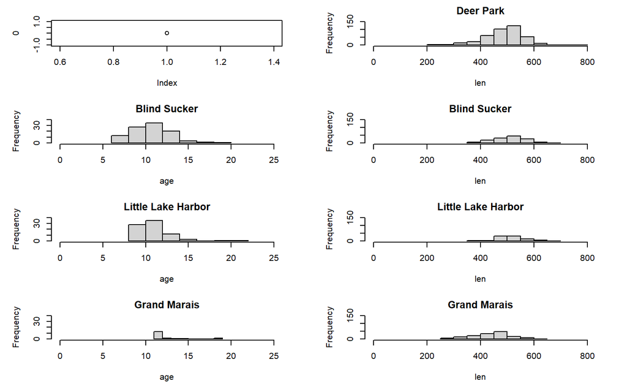

```r
par(mfrow=c(4,2), mar=c(5,5,2,3))
for (j in 1:length(loca)) {
  rindex <- which(fish$locID==loca[j])
  age <- fish[rindex,"age"]
  len <- fish[rindex,"len"]
  if (!all(is.na(age))) {
  hist(age, main=loca[j], xlim=c(0,25), ylim=c(0,40))
  hist(len, main=loca[j], xlim=c(0,800), ylim=c(0,150))
  } else {
    plot(0)
    hist(len, main=loca[j], ylim=c(0,150), xlim=c(0,800))
  }
}
```

Couple of things to note here. Deer Park has a big sample size and no age data. Grand Marais sampled trout represent a smaller age range and may be smaller. This leads me to be curious about the sampling protocol. But first, I checked out the length-weight relationship by location.

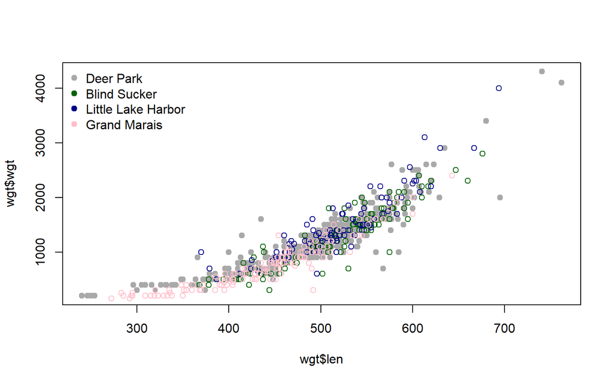

```r
par(mfrow=c(1,1))
for (k in 1:length(loca)) {
  wgt <- fish[fish$locID==loca[k],]
  if (k ==1) {
    plot(x=wgt$len,
         y=wgt$wgt,
         pch=19,
         col=colr[k])
  } else {
    points(x=wgt$len,
           y=wgt$wgt,
           pch=21,
           col=colr[k])
  }

}

legend(x="topleft",
       legend=loca,
       col=colr,
       pch=19,
       bty="n")
```

## You know what grinds my Gears?

People who chew with their mouth open. But that is neither here nor there. I’m curious about how many mesh sizes there are and how frequently there were used, by location.

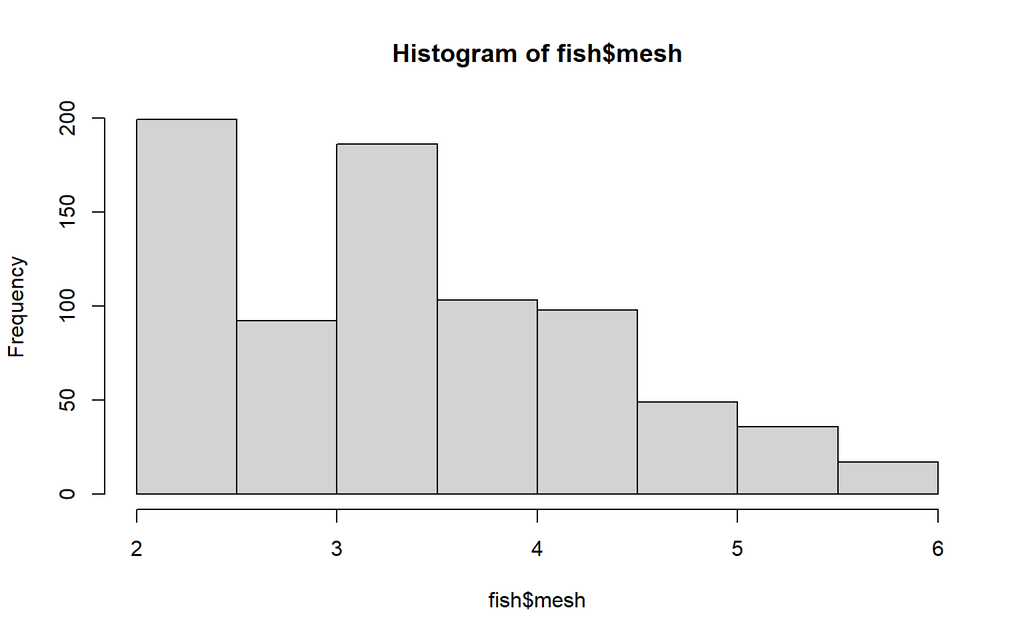

```r
#Fish count by mesh size?
meshbins <- unique(fish$mesh)
hist(fish$mesh)
```

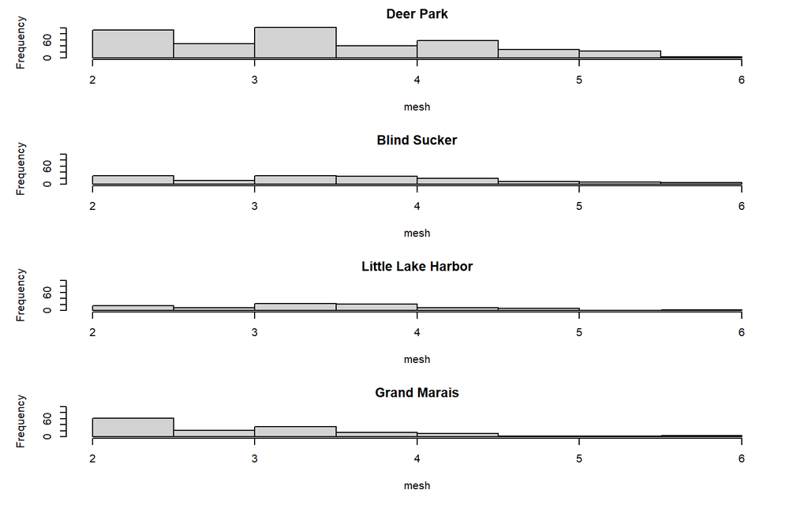

```r
# Fish count by mesh size by location?
par(mfrow=c(4,1), mar=c(5,5,2,3))
for (h in 1:length(loca)) {
  rindex <- which(fish$locID==loca[h])
  mesh <- fish[rindex,"mesh"]
  hist(mesh, main=loca[h], ylim=c(0,100))
}
```

I’m not super surprised here. Mesh size use was likely a part of the experimental design, so you would hope to see the same nets used at every location. Here’s where I anticipate to see differences:

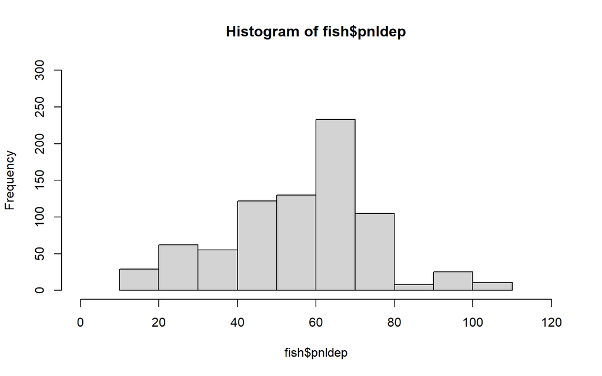

```r
par(mfrow=c(1,1))
# Fish count by depth?
hist(fish$pnldep,
     xlim=c(0,120),
     ylim=c(0,300))
```

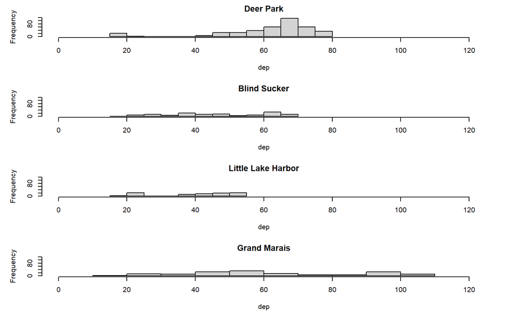

```r
# Fish count by depth by location?
par(mfrow=c(4,1), mar=c(5,5,2,3))
for (m in 1:length(loca)) {
  rindex <- which(fish$locID==loca[m])
  dep <- fish[rindex,"pnldep"]
  hist(dep, main=loca[m],
       ylim=c(0,120), xlim=c(0,120))

}
```

If I were a betting woman, I would guess that these four locations have different physical features, like depth. I was most surprised to see Grand Marais having the widest range of depths sampled because my working hypothesis was that it had a more limited depth range and perhaps that is why we saw a subset age range and smaller trout.

I was curious if there were any sex-specific differences in depth.

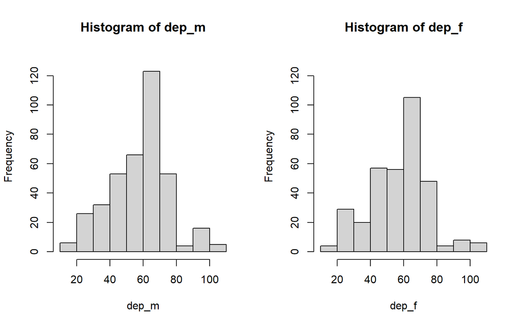

```r
# sex and depth
dep_m <- fish[fish$sex=="M","pnldep"]
dep_f <- fish[fish$sex=="F", "pnldep"]

par(mfrow=c(1,2))
hist(dep_m, ylim=c(0,130))
hist(dep_f, ylim=c(0,130))
```

But this again yields nothing to write home about.

# Data exposition

I decided to plot the length-weight relationship by location and mesh size. I thought it would be interesting to see what the length and weight frequencies by location would look like as marginal plots. I have to stop for now, but to further make this a publication ready plot: larger font sizes all around and fiddling around to minimize the large amount of whitespace. I suspect this could have been easier if I used `ggplot2`, but this was faster than me learning how to use that package.

The code is hideous, so I’ll make a visable copy below this plot.

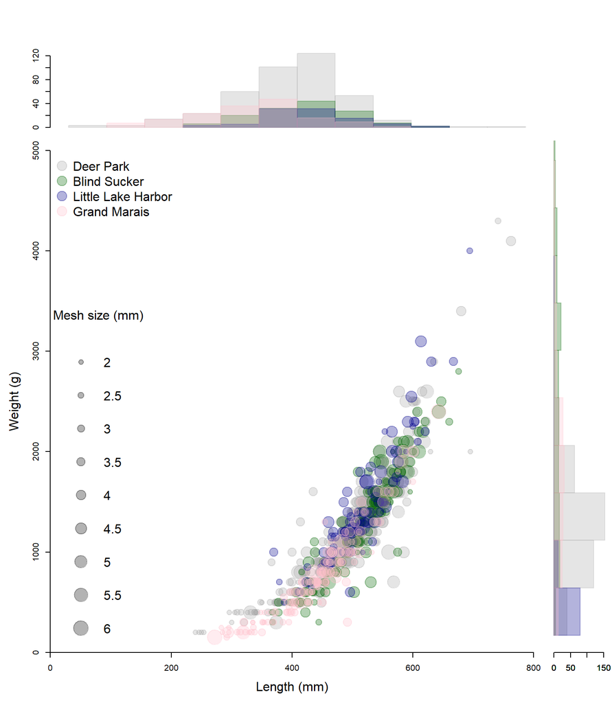

## Exposition plot code

```r
# This creates lists of hist() to be used later for overplotting
# xhist <- hist(fish$wgt[-out])
histlist <- list()

for (ii in 1:length(loca)) {
  len <- fish[fish$locID==loca[ii],]
  histlist[[ii]] <- hist(len$len,
                         xlim=c(0,800),
                         main="",
                         xaxt="n",
                         xlab="",
                         ylab="",
                         border=alpha(colr[ii], 0.3),
                         col=alpha(colr[ii], 0.3))
}
```

```r
histlist2 <- list()
for (ii in 1:length(loca)) {
  len <- fish[fish$locID==loca[ii],]
  histlist2[[ii]] <- hist(len$wgt,
                         xlim=c(0,5000),
                         main="",
                         xaxt="n",
                         xlab="",
                         ylab="",
                         border=alpha(colr[ii], 0.3),
                         col=alpha(colr[ii], 0.3))
}
```

```r
mat <- matrix(c(1,2,1,2,0,3), ncol=3)

# I used layout() so I could have a multipanel plot of different sizes
layout(mat, widths=c(5,3), heights=c(0.5,2))
# layout.show(3)

# overplot the length histogram in the first row of layout
par(mar=c(1,5,5,0))

for (ii in 1:length(loca)) {
  if (ii==1) {
    plot(histlist[[ii]],
     border=alpha(colr[ii], 0.3),
     col=alpha(colr[ii], 0.3),
     xaxt="n",
     ylab="",
     main="")
  } else {
    plot(histlist[[ii]],
     border=alpha(colr[ii], 0.3),
     col=alpha(colr[ii], 0.3), add=T)
  }
}

# Plot the length-weight relationship
par(mar=c(5,5,1,1))
for (k in 1:length(loca)) {
  wgt <- fish[fish$locID==loca[k],]
  if (k ==1) {
    plot(x=wgt$len,
         y=wgt$wgt,
         pch=20,
         cex=wgt$mesh,
         col=alpha(colr[k], 0.3),
         ylab="Weight (g)",
         xlab="Length (mm)",
         bty="l",
         xlim=c(0,800),
         ylim=c(0,5000),
         xaxs="i",
         yaxs="i",
         cex.lab=1.5)
  } else {
    points(x=wgt$len,
           y=wgt$wgt,
           pch=20,
           cex=wgt$mesh,
           col=alpha(colr[k], 0.3))
  }

}
# Location legend
legend(x="topleft",
       legend=loca,
       col=alpha(colr, 0.3),
       pch=20,
       pt.cex=4,
       bty="n",
       horiz=F,
       cex=1.5)

# Mesh size legend
legend(x="bottomleft",
       legend=sort(unique(wgt$mesh)),
       pch=20,
       y.intersp=2.2,
       x.intersp=2,
       bty="n",
       xpd=F,
       pt.cex=sort(unique(wgt$mesh)),
       title="Mesh size (mm)",
       col=alpha("black", 0.3),
       cex=1.5)

# Overplot the weight histogram by location
par(mar=c(5,1,5,0))

for (jj in 1:length(loca)) {
  if (jj==1) {
    barplot(histlist2[[jj]]$counts,
            horiz=T,
            space=0,
            xlim=c(0,175),
            yaxt="n",
            border=alpha(colr[jj], 0.3),
            col=alpha(colr[jj], 0.3))
  } else {
        barplot(histlist2[[jj]]$counts,
            horiz=T,
            space=0,
            xlim=c(0,175),
            yaxt="n",
            border=alpha(colr[jj], 0.3),
            col=alpha(colr[jj], 0.3),
            add=T)
  }

}
```